# Supervied Learning Assignment

Mark Lewis, Daniyal Shamim, Juan Calvillo, Salman Amin

February 17, 2019

## R Markdown

This is an R Markdown of a walkthrough for out assignment The data set we used was taken from UCI machine learning repository Which can be found here https://archive.ics.uci.edu/ml/datasets/Census+Income A link to the RShint app can be found here https://markglewis.shinyapps.io/IncomePrediction/ To begin install the following packages

```r
#import packages;
library(dplyr)
```

```r
library(reshape2)
library(ggplot2)
library(Hmisc)
library(corrplot)
library(mice)
library(VIM)
library(pROC)
library(caret)
library(sqldf)
library(rpart)
library(e1071)
library(C50)
```

Import the data set Give Collumns names for readability

```
## [1] "C:/code/ML York/Assignment 1"
```

```
## 'data.frame':    32561 obs. of  16 variables:
##  $ age           : int  39 50 38 53 28 37 49 52 31 42 ...
##  $ workclass     : Factor w/ 9 levels " ?"," Federal-gov",..: 8 7 5 5 5 5 5 7 5 5 ...
##  $ fnlwgt        : int  77516 83311 215646 234721 338409 284582 160187 209642 45781 159449 ...
##  $ education     : Factor w/ 16 levels " 10th"," 11th",..: 10 10 12 2 10 13 7 12 13 10 ...
##  $ education-num : int  13 13 9 7 13 14 5 9 14 13 ...
##  $ marStat       : Factor w/ 7 levels " Divorced"," Married-AF-spouse",..: 5 3 1 3 3 3 4 3 5 3 ...
##  $ occupation    : Factor w/ 15 levels " ?"," Adm-clerical",..: 2 5 7 7 11 5 9 5 11 5 ...
##  $ relationship  : Factor w/ 6 levels " Husband"," Not-in-family",..: 2 1 2 1 6 6 2 1 2 1 ...
##  $ race          : Factor w/ 5 levels " Amer-Indian-Eskimo",..: 5 5 5 3 3 5 3 5 5 5 ...
##  $ sex           : Factor w/ 2 levels " Female"," Male": 2 2 2 2 1 1 1 2 1 2 ...
##  $ capital-gain  : int  2174 0 0 0 0 0 0 0 14084 5178 ...
##  $ capital-loss  : int  0 0 0 0 0 0 0 0 0 0 ...
##  $ hrs-per-week  : int  40 13 40 40 40 40 16 45 50 40 ...
##  $ native-country: Factor w/ 42 levels " ?"," Cambodia",..: 40 40 40 40 6 40 24 40 40 40 ...
##  $ income        : Factor w/ 2 levels " <=50K"," >50K": 1 1 1 1 1 1 1 2 2 2 ...
##  $ ID            : int  1 2 3 4 5 6 7 8 9 10 ...
```

```
##       age                    workclass         fnlwgt
##  Min.   :17.00    Private         :22696   Min.   :  12285
##  1st Qu.:28.00    Self-emp-not-inc: 2541   1st Qu.: 117827
##  Median :37.00    Local-gov       : 2093   Median : 178356
##  Mean   :38.58    ?               : 1836   Mean   : 189778
##  3rd Qu.:48.00    State-gov       : 1298   3rd Qu.: 237051
##  Max.   :90.00    Self-emp-inc    : 1116   Max.   :1484705
##                  (Other)          :  981
##          education     education-num                     marStat
##   HS-grad     :10501   Min.   : 1.00    Divorced             : 4443
##   Some-college: 7291   1st Qu.: 9.00    Married-AF-spouse    :   23
##   Bachelors   : 5355   Median :10.00    Married-civ-spouse   :14976
##   Masters     : 1723   Mean   :10.08    Married-spouse-absent:  418
##   Assoc-voc   : 1382   3rd Qu.:12.00    Never-married        :10683
##   11th        : 1175   Max.   :16.00    Separated            : 1025
##  (Other)      : 5134                    Widowed              :  993
##             occupation            relationship
##   Prof-specialty :4140    Husband       :13193
##   Craft-repair   :4099    Not-in-family : 8305
##   Exec-managerial:4066    Other-relative:  981
##   Adm-clerical   :3770    Own-child     : 5068
##   Sales          :3650    Unmarried     : 3446
##   Other-service  :3295    Wife          : 1568
##  (Other)         :9541
##                   race            sex         capital-gain
##   Amer-Indian-Eskimo:  311    Female:10771   Min.   :    0
##   Asian-Pac-Islander: 1039    Male  :21790   1st Qu.:    0
##   Black             : 3124                   Median :    0
##   Other             :  271                   Mean   : 1078
##   White             :27816                   3rd Qu.:    0
##                                              Max.   :99999
##
##   capital-loss     hrs-per-week          native-country     income
##  Min.   :   0.0   Min.   : 1.00    United-States:29170    <=50K:24720
##  1st Qu.:   0.0   1st Qu.:40.00    Mexico       :  643    >50K : 7841
##  Median :   0.0   Median :40.00    ?            :  583
##  Mean   :  87.3   Mean   :40.44    Philippines  :  198
##  3rd Qu.:   0.0   3rd Qu.:45.00    Germany      :  137
##  Max.   :4356.0   Max.   :99.00    Canada       :  121
##                                   (Other)       : 1709
##        ID
##  Min.   :    1
##  1st Qu.: 8141
##  Median :16281
##  Mean   :16281
##  3rd Qu.:24421
##  Max.   :32561
##
```

search for missing data

```
## [1] 4262
```

```
## [1] 0.008180799
```

erase those rows we dont need those

lets see if there are any outliers in the data set

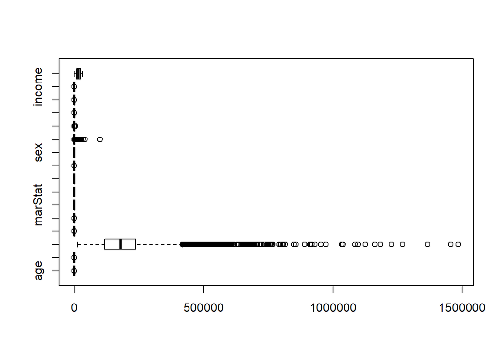

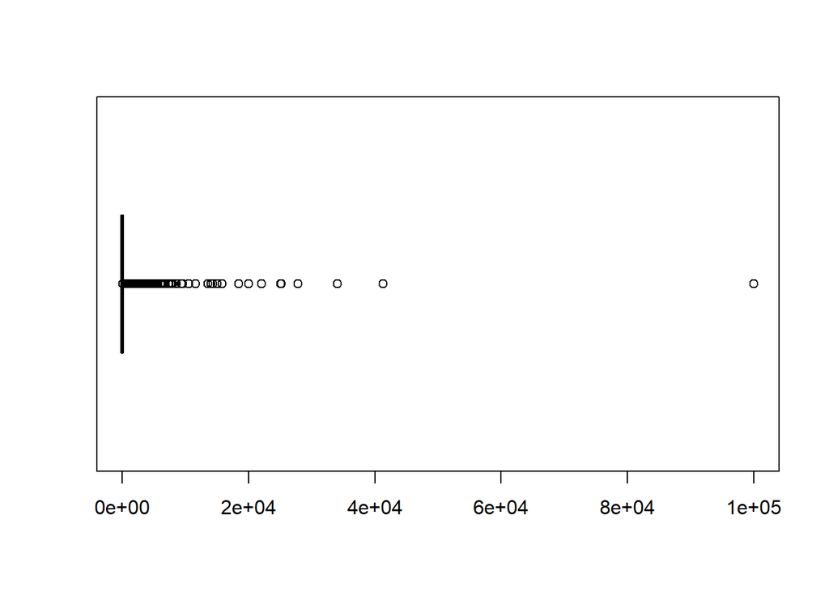

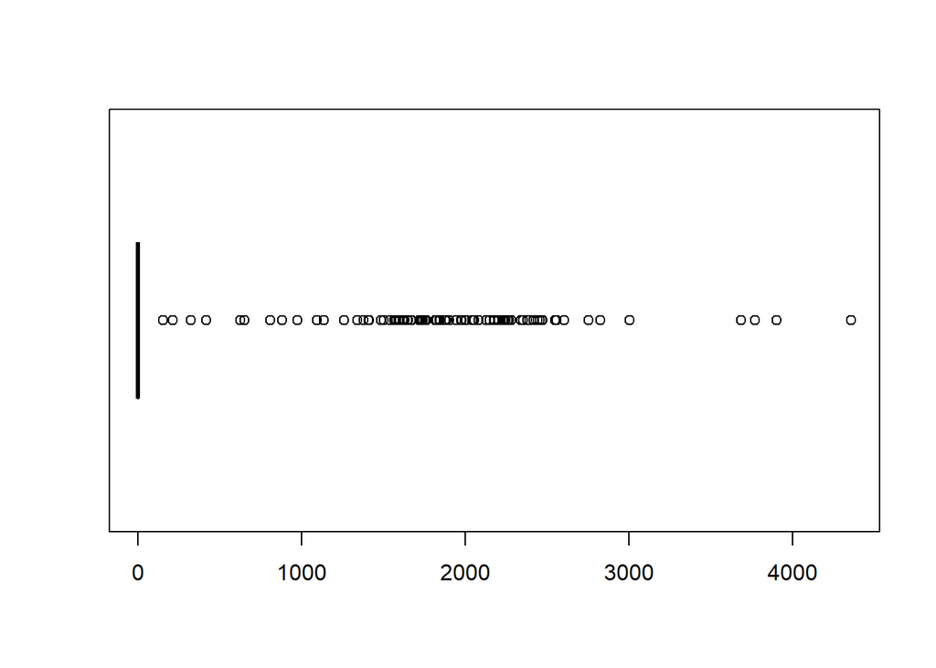

as shown the data with the most outliers and inconsistency are: fnlwgt data$'capital-gain data$’capital-loss data$’native-country

Let’s do some data exploration

```
## workclass
##             ?   Federal-gov     Local-gov  Never-worked       Private
##             0           943          2067             0         22286
##  Self-emp-inc
##          1074
```

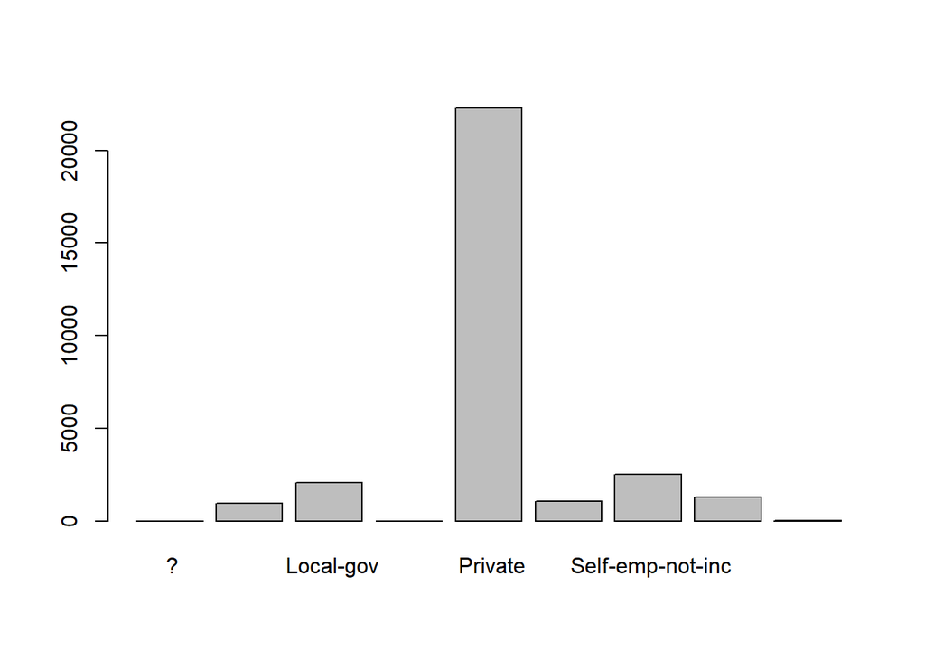

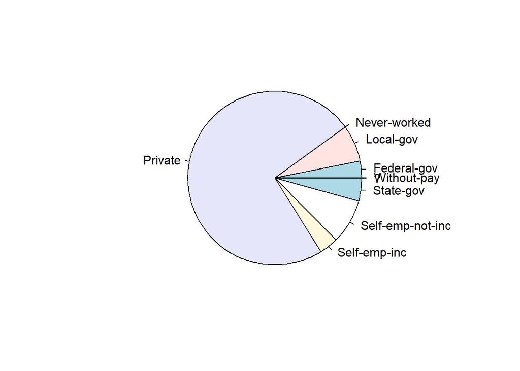

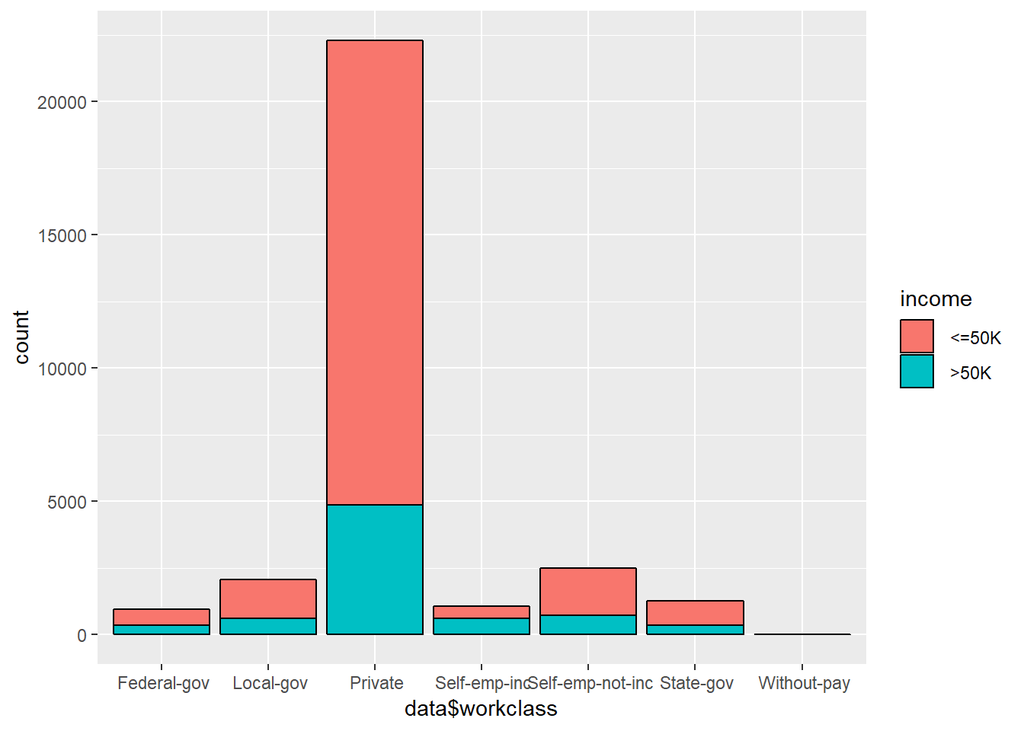

As shown here the vast majority of people in this set are low in income and work for private companies This would lead me to believe that this data is heavily biased

```
## education
##     10th     11th     12th  1st-4th  5th-6th  7th-8th
##      820     1048      377      151      288      557
```

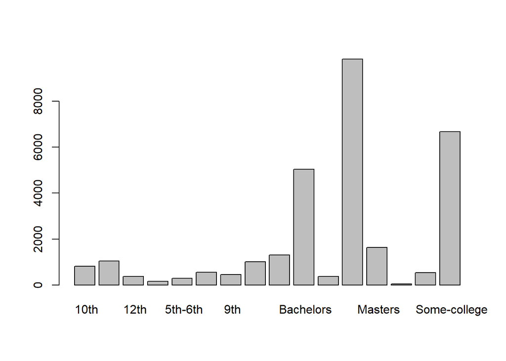

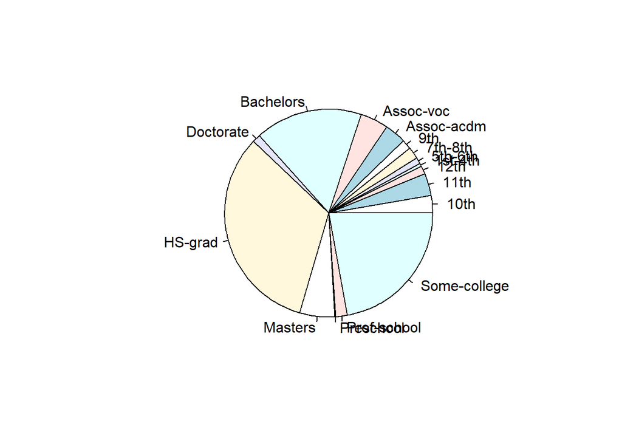

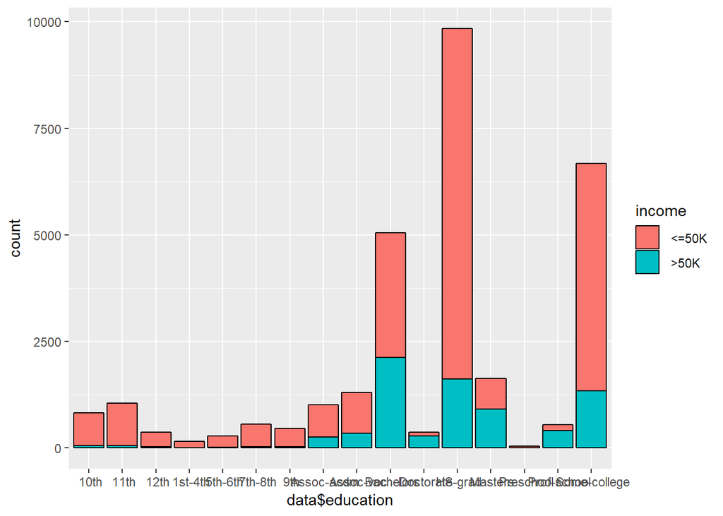

```
## marStat
##               Divorced      Married-AF-spouse     Married-civ-spouse
##                   4214                     21                  14065
##  Married-spouse-absent          Never-married              Separated
##                    370                   9726                    939
```

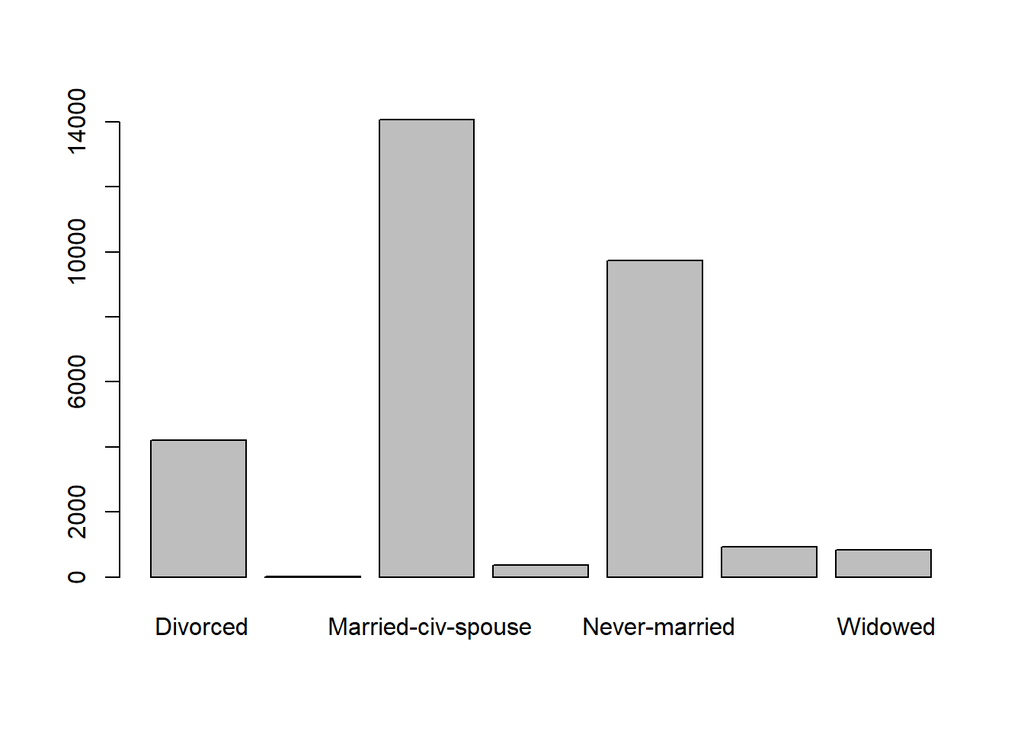

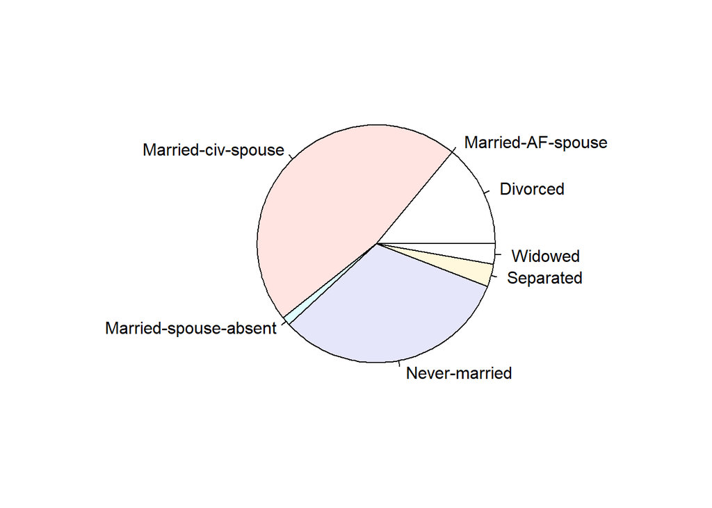

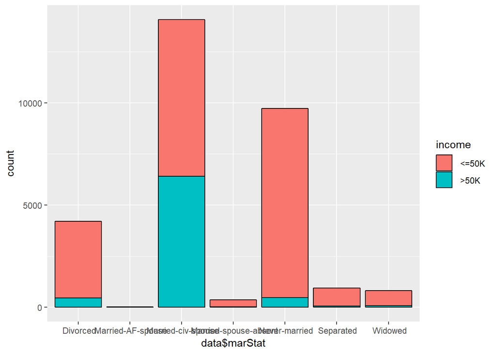

Doesn’t seem appropriately representative

```
## occupation
##                ?     Adm-clerical     Armed-Forces     Craft-repair
##                0             3721                9             4030
##  Exec-managerial  Farming-fishing
##             3992              989
```

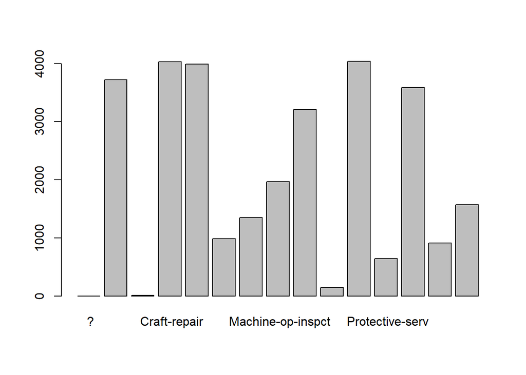

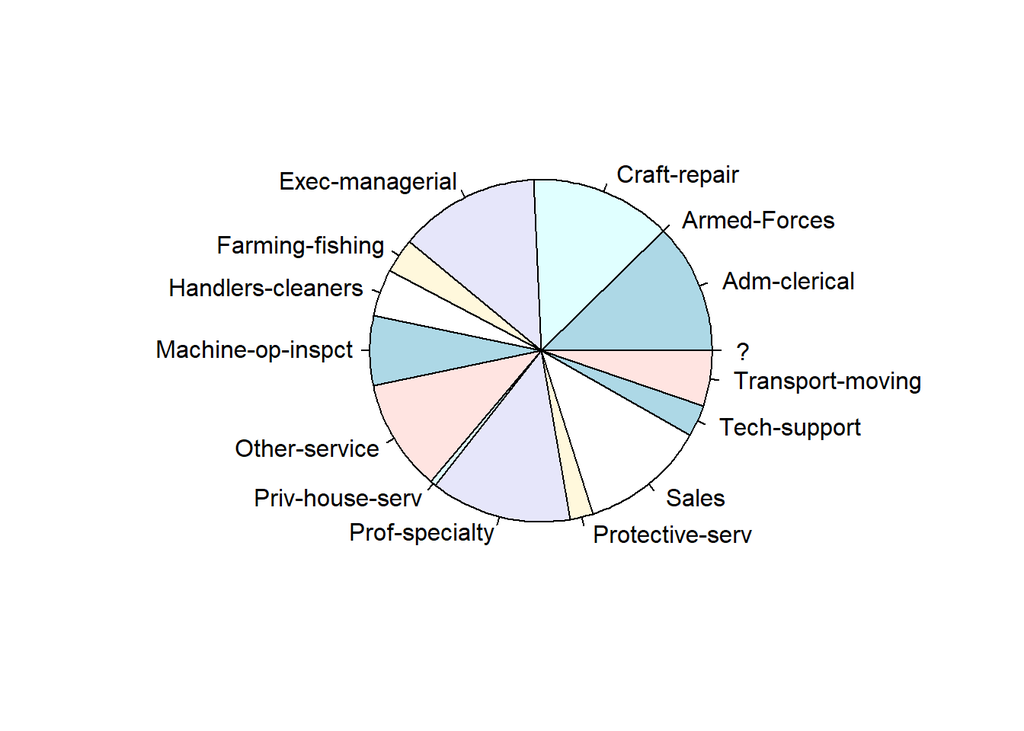

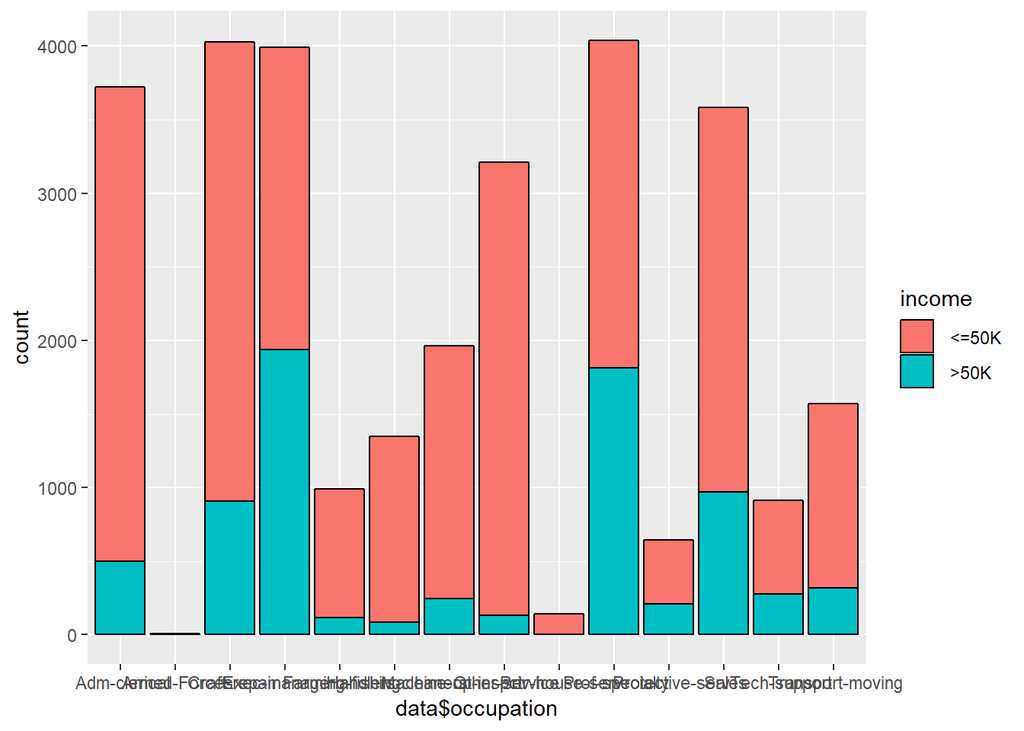

```
## relationship
##         Husband   Not-in-family  Other-relative       Own-child
##           12463            7726             889            4466
##       Unmarried            Wife
##            3212            1406
```

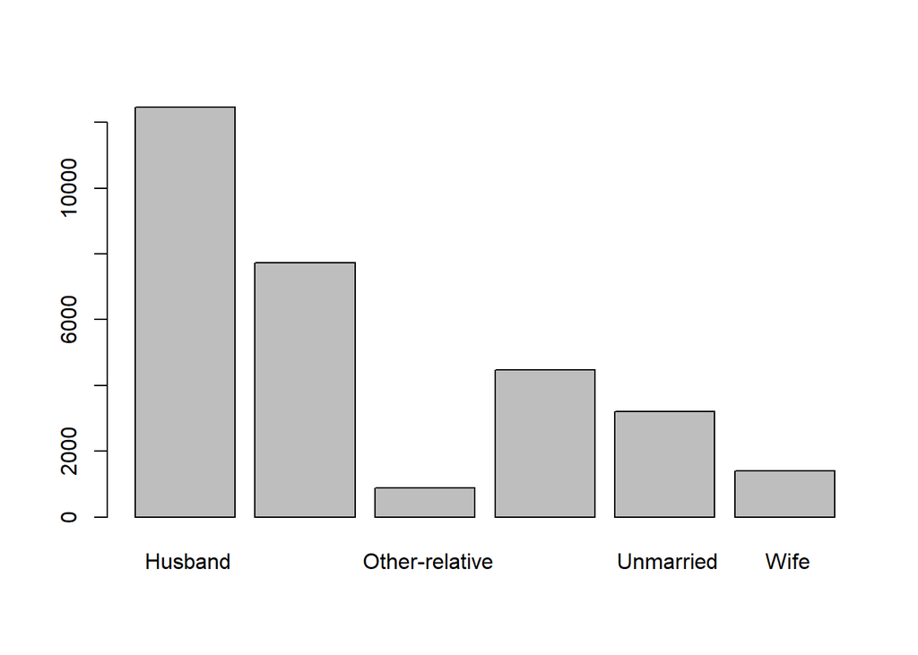

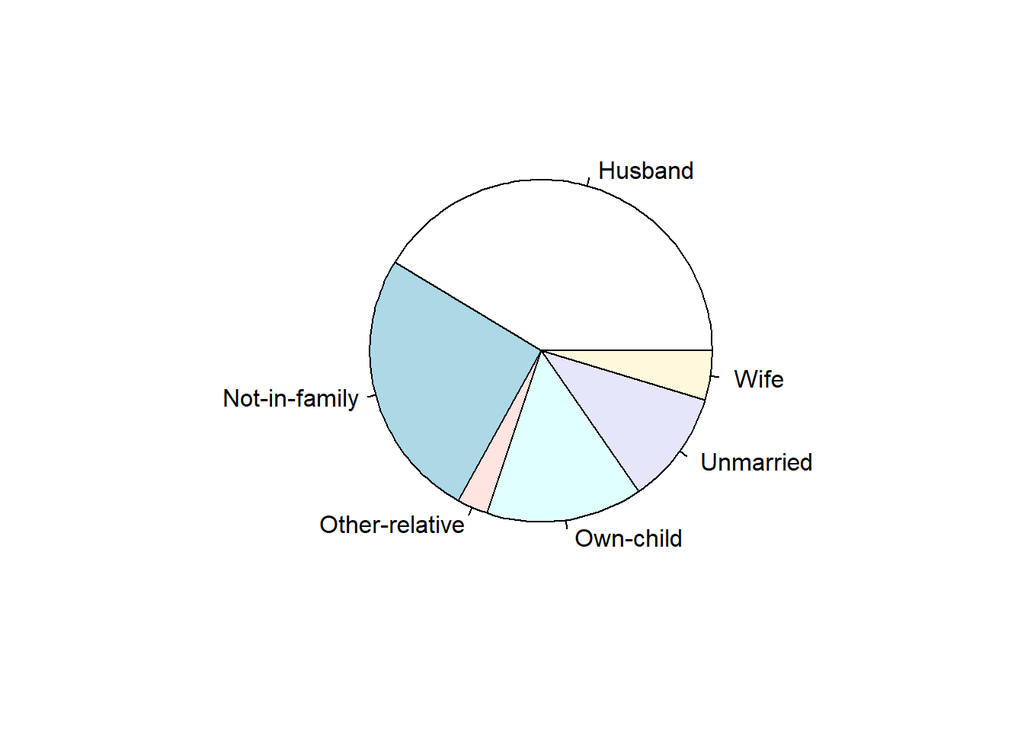

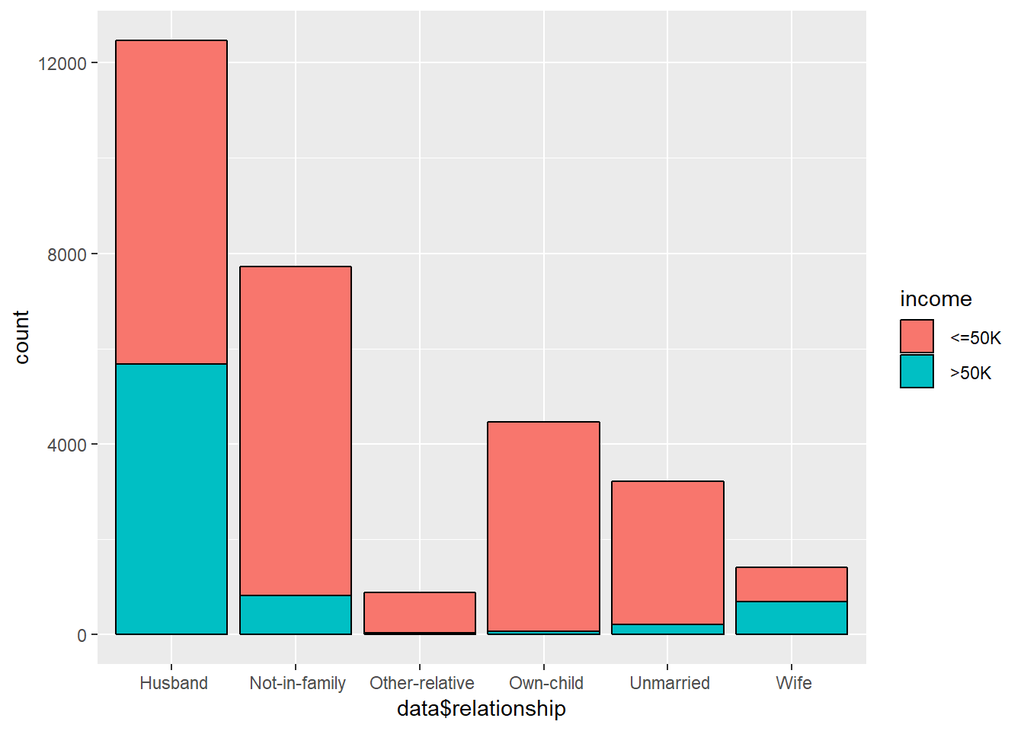

There are more husbands than wives in this set. that’s not a good sign.

```
## race
##  Amer-Indian-Eskimo  Asian-Pac-Islander               Black
##                 286                 895                2817
##               Other               White
##                 231               25933
```

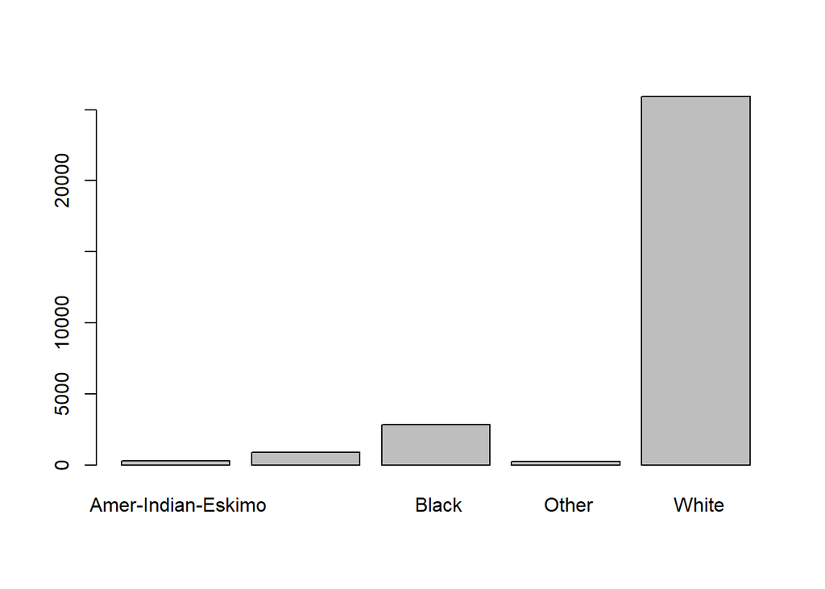

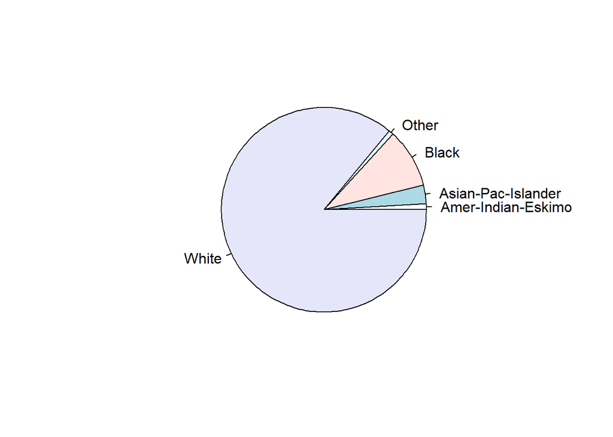

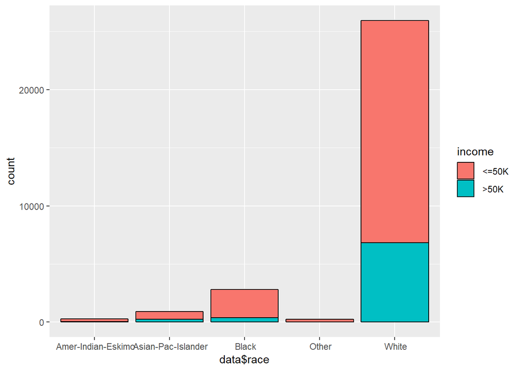

The data clearly has a massive bias at this point

```
## sex
##  Female    Male
##    9782   20380
```

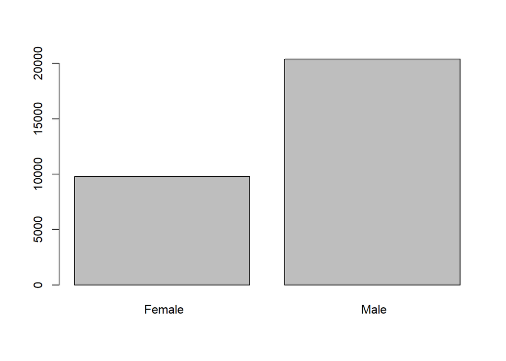

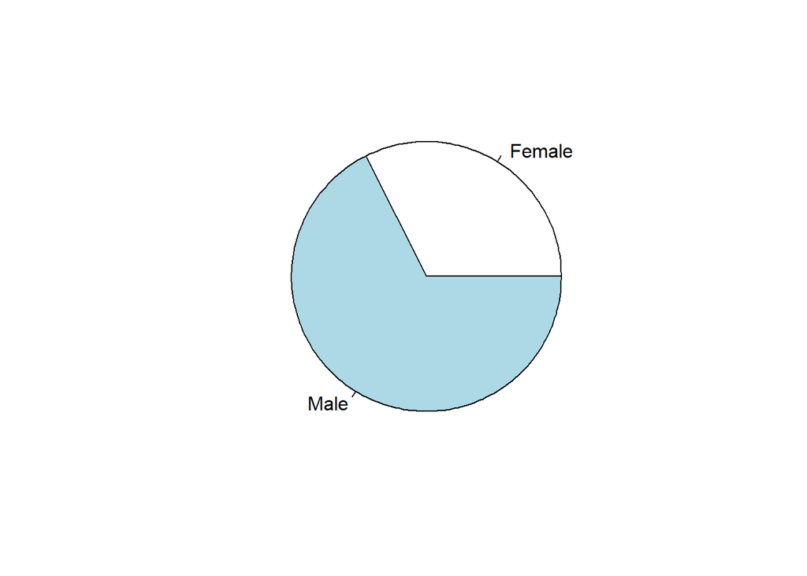

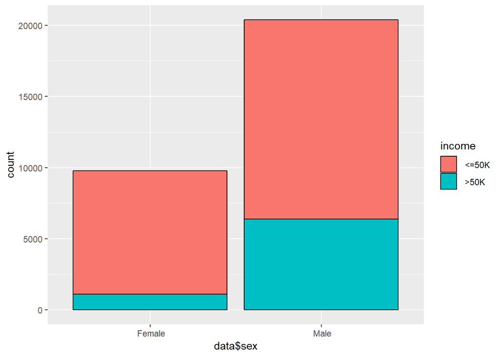

```
## integer(0)
```

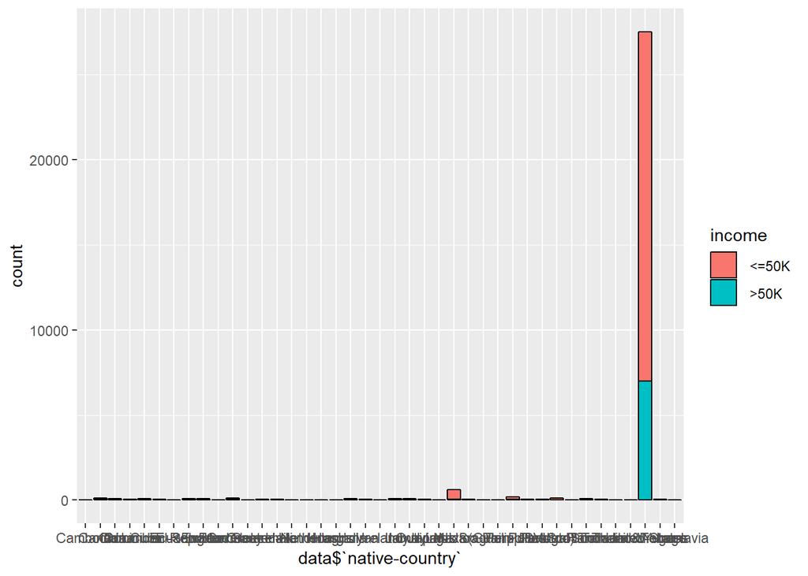

Data was mostly taken from one country

Lets look at all the data side by side

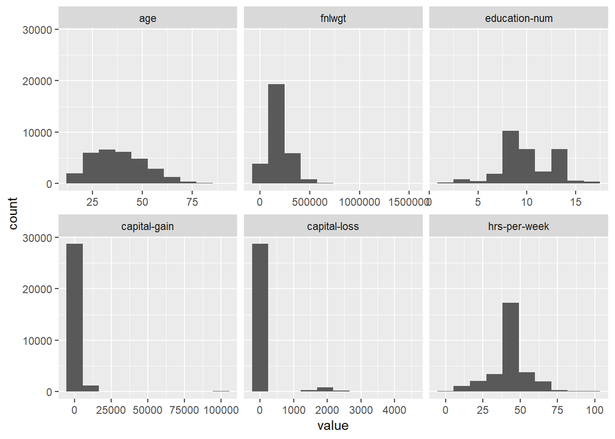

Seems like the only unbiased variable was age

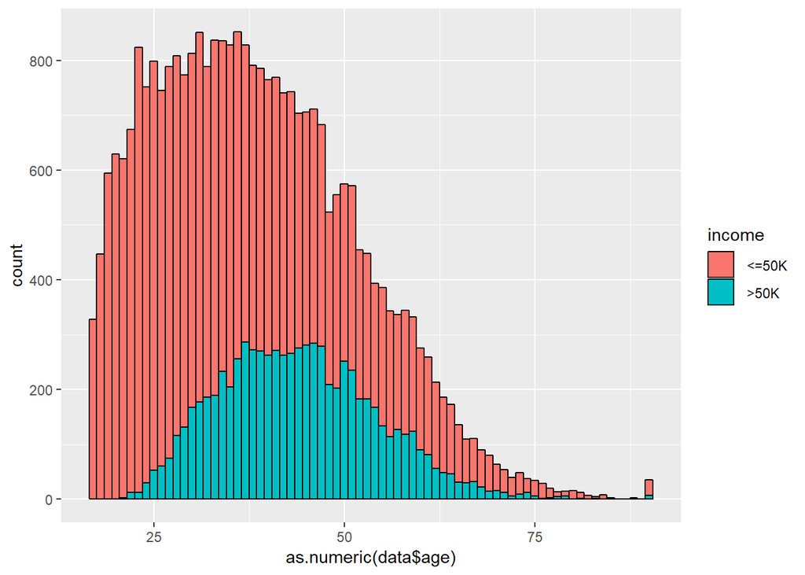

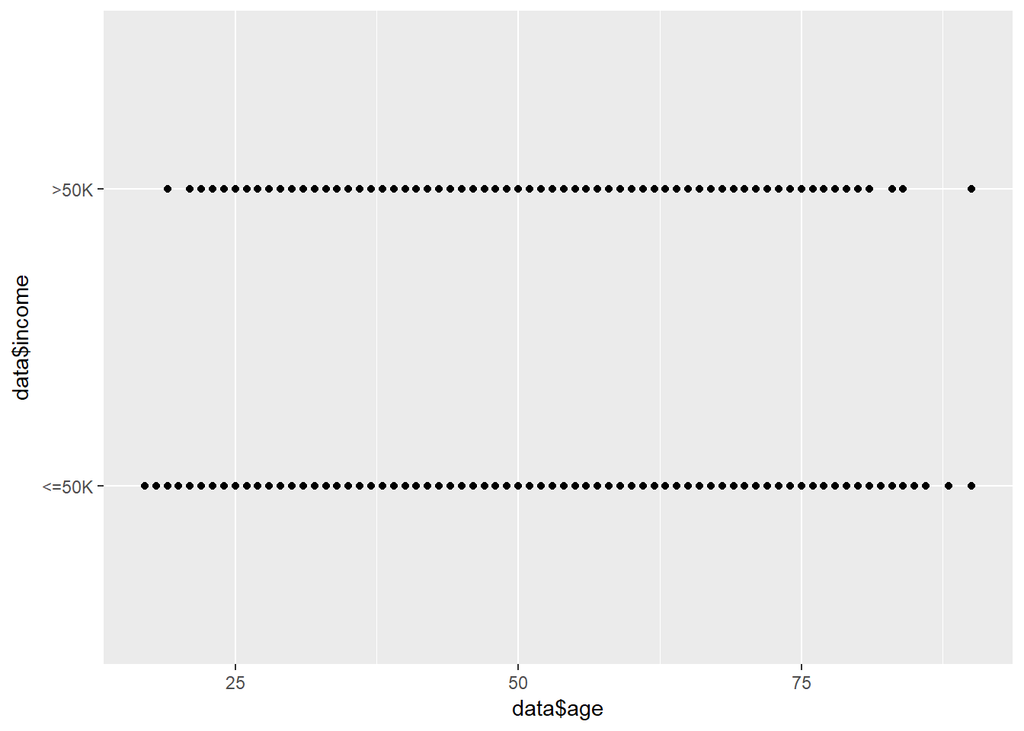

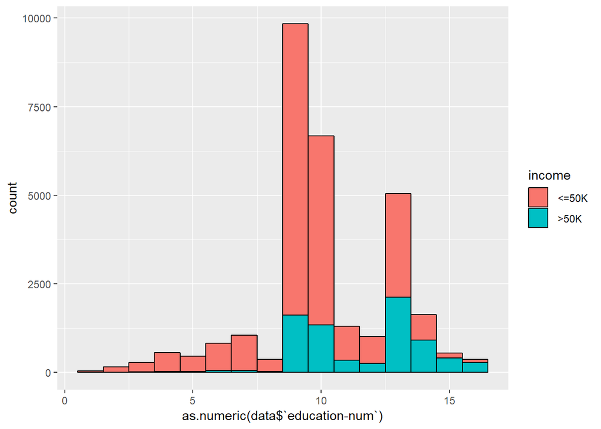